# Session 5: SNPs_handling_vcf_filtering

Apollo Lizano; Le Qin Choo

2025-03-22

In the previous session, we covered how to call variants and manage VCF files. In this session, we’ll dive into filtering VCFs—a task that might seem straightforward at first glance but is actually crucial to getting reliable results. Careful and thoughtful filtering is essential, as it can significantly impact the accuracy and interpretation of your data

## Check the size of our .vcf.gz file

```bash
ls -lh *.vcf.gz
```

You will see that this VCF is 405Mb in size, which is quite large but real analyses with many individuals can run to much larger sizes than this (for instance, we regularly work with VCF files containing hundreds of individuals which are >300 G).

## How many unfiltered variants?

One thing we didn’t check yet is how many variants we actually have. Each line in the main output of a vcf represents a single call so we can use the following code to work it out:

```bash
bcftools view -H filename.vcf.gz | wc -l
```

Tip: You will use this command a lot so please keep this in mind!

This command will print every line of the VCF file, which can take a long time if the file is large. To avoid being tied up while it runs, it’s a good idea to execute it inside a screen session so you can check back later.

Our full VCF contains nearly 6 million variants—a substantial number! However, many of these variants may not be useful for analysis due to low minor allele frequency, insufficient coverage depth, or being present in too few individuals.

At this point, we haven’t applied any filters, and that’s intentional—we want to observe the impact of filtering firsthand. Still, it’s useful to perform an initial analysis to guide filter setting, keeping in mind that processing such a large VCF can be time-consuming.

## Generating statistics for VCF

In order to generate statistics from our VCF and also actually later apply filters, we are going to use vcftools, a very useful and fast program for handling vcf files.

Here is the link to vcftools page if you wanted to explore more: https://vcftools.github.io/examples.html

### Important

Setting filters on a dataset can be daunting—even experienced researchers often struggle with it. There’s rarely a single “correct” way to do it; what matters most is being able to justify your choices. **The key is to thoroughly understand your data and use that knowledge to establish sensible thresholds.**

Fortunately, `VCFtools` makes it easy to calculate statistics that help guide your decisions. In this section, we’ll analyze our `VCF file` to develop a clear strategy for setting filtering thresholds. We’ll focus on four main areas:

**1. Depth:** Always include a minimum depth filter, and ideally, a maximum depth filter as well.

A minimum depth cutoff helps remove false positive calls and ensures higher-quality data.

A maximum depth cutoff is crucial because regions with excessively high read depths are likely repetitive, mapping to multiple parts of the genome.

**2. Quality:** Genotype quality is essential—never trust genotypes with a Phred score below 20, as this indicates less than 99% accuracy. Applying a quality filter helps maintain the reliability of your data.

**3. Minor Allele Frequency (MAF):** MAF can significantly affect SNP calls and may inflate downstream statistical estimates.

Ideally, you should examine the distribution of allele frequencies before setting a threshold.

A reasonable cutoff is typically between 0.05 and 0.10, but be cautious—certain analyses, such as demographic inference, can be biased by MAF thresholds.

**4. Missing Data:** Decide how much missing data you’re willing to tolerate. This can vary depending on your study, but as a general rule, any site with more than 25% missing data should be excluded.

By carefully considering these aspects, you can set robust and well-justified filtering thresholds, ensuring more reliable downstream analyses.

## Setting up

Before we calculate our stats, let’s make a little effort to make our commands simpler and also to ensure the output is written to the right place. First we need to make a directory for our results.

```bash
mkdir vcftools
```

Next we will declare to variables to save us some typing below.

```bash
SUBSET_VCF=/home/apl/NAS_apl/milkfish/milkfish_snps_filtered.vcf.gz
OUT=/home/apl/NAS_apl/milkfish/vcftools/milkfish_filtered
```

SUBSE_VCF=path/input file.gz

OUT=path/outputfilename

### 1. Calculate allele frequency

First we will calculate the allele frequency for each variant. The –freq2 just outputs the frequencies without information about the alleles, –freq would return their identity. We need to add `max-alleles 2` to exclude sites that have more than two alleles.

```bash
vcftools --gzvcf $SUBSET_VCF --freq2 --out $OUT --max-alleles 2
```

Check your output directory file. A new file should be generated. If not, there is something wrong with the command you ran or the input / output information.

### 2. Calculate mean depth per individual

Next we calculate the mean depth of coverage per individual.

```bash
vcftools --gzvcf $SUBSET_VCF --depth --out $OUT
```

### 3. Calculate mean depth per site

Similarly, we also estimate the mean depth of coverage for each site.

```bash
vcftools --gzvcf $SUBSET_VCF --site-mean-depth --out $OUT
```

### 4. Calculate site quality

We additionaly extract the site quality score for each site.

```bash
vcftools --gzvcf $SUBSET_VCF --site-quality --out $OUT
```

### 5. Calculate proportion of missing data per individual

Another individual level statistic - we calculate the proportion of missing data per sample.

```bash
vcftools --gzvcf $SUBSET_VCF --missing-indv --out $OUT
```

### 6. Calculate proportion of missing data per site

And more missing data, just this time per site rather than per individual.

```bash
vcftools --gzvcf $SUBSET_VCF --missing-site --out $OUT
```

### 7. Calculate heterozygosity and inbreeding coefficient per individual

Computing heterozygosity and the inbreeding coefficient (F) for each individual can quickly highlight outlier individuals that are e.g. inbred (strongly negative F), suffer from high sequencing error problems or contamination with DNA from another individual leading to inflated heterozygosity (high F), or PCR duplicates or low read depth leading to allelic dropout and thus underestimated heterozygosity (stongly negative F). However, note that here we assume Hardy-Weinberg equilibrium. If the individuals are not sampled from the same population, the expected heterozygosity will be overestimated due to the Wahlund-effect. It may still be worth to compute heterozygosities even if the samples are from more than one population to check if any of the individuals stands out which could indicate problems.

```bash
vcftools --gzvcf $SUBSET_VCF --het --out $OUT
```

With the statistics calculated, take a moment to have a quick look at the output in the `vcftools` directory. We will now need to download our output data onto our local machines in order to work with R.

## Examining statistics in R

First, go to your R studio. Make sure you are in the right directory by going to Session > Set Working Directory > Choose Directory > Directory where all the files are saved.

### 1. Setting-up the environment

First load the `tidyverse` package and ensure you have moved the vcftools output into the working directory you are operating in. You may want to set up an RStudio Project to manage this analysis. See here for a guide on how to do this.

```bash
# load tidyverse package
library(tidyverse)
```

### 2. Variant based statistics

The first thing we will do is look at the statistics we generated for each of the variants in our subset VCF - **quality**, **depth**, **missingness** and **allele frequency**.

#### 2.1. Variant quality

The first metric we will look at is the (Phred encoded) site quality. This is a measure of how much confidence we have in our variant calls. First of all, we read in the site quality report we generated using vcftools. We will use the read_delim command from the readr package (part of the the tidyverse) because it is more efficient for reading in large datafiles. It also allows us to set our own column names.

```bash
var_qual <- read_delim("./milkfish_filtered.lqual", delim = "\t",
           col_names = c("chr", "pos", "qual"), skip = 1)
```

Take a look at the data when it is read in. You will see that for each site in our VCF, we have extracted the site quality score. Now we will plot the distribution of this quality using `ggplot`. Usually, the `geom_density` function works best, but you can use `geom_histogram` too.

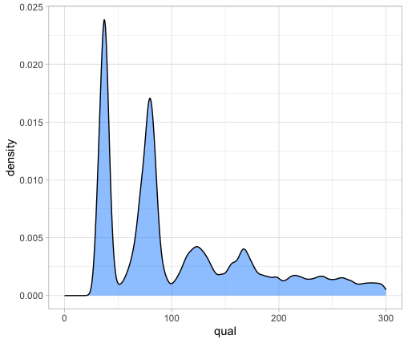

Fig 1. Quality of filtered reads (phread score).

```bash
a <- ggplot(var_qual, aes(qual)) + geom_density(fill = "dodgerblue1", colour = "black", alpha = 0.3)
a + theme_light()
```

From this we can see that quality scores are actually very high for our sites. Remember that a Phred score of `30` represents a `1 in 1000` chance that our SNP call is erroneous. Clearly most sites exceed this - suggesting we have a lot of high confidence calls. This is most probably because we have sufficient read depth (as you will see in the next section). However since most sites have a high quality we can see that filtering on this is not really going to be that useful.

##### 2.2. Variant mean depth

Next we will examine the *mean depth for each of our variants*. This is essentially the *number of reads that have mapped to this position*. The output we generated with vcftools is the mean of the read depth across all individuals - it is for both alleles at a position and is not partitioned between the reference and the alternative.

First we read in the data.

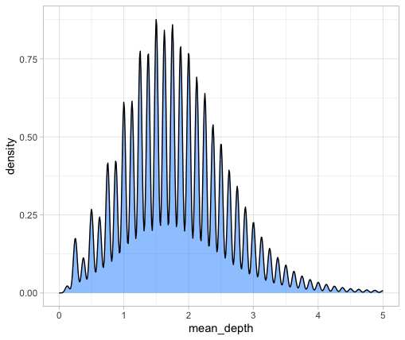

```bash
var_depth <- read_delim("milkfish_filtered.ldepth.mean", delim = "\t",
           col_names = c("chr", "pos", "mean_depth", "var_depth"), skip = 1)


a <- ggplot(var_depth, aes(mean_depth)) + geom_density(fill = "dodgerblue1", colour = "black", alpha = 0.5)
a + theme_light()+ xlim(0, 5)
```

Again take a moment to look at the data - mean_depth is our column of interest but note that you can also get a an idea of the variance in depth among individuals from the `var_depth column`. Once again, we will use ggplot to look at the distribution of read depths. `See Figure 2`.

```bash
summary(var_depth$mean_depth)
## Most variants have a depth of 2x
##Range 0.125-1612 (big range)
## Use formula mean depth + (2*SD)
##minimum is 0.5 (conservative estimates) and 4 as maximum depth (avoid erroneous calls)
```

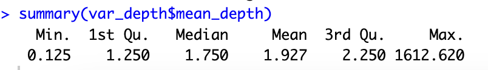

Fig 3. Summary of depth of each variants).

Since we all took different subsets, these values will likely differ slightly but clearly in this case most variants have a depth of 0-5x whereas there are some extreme outliers. We will redraw our plot to exclude these and get a better idea of the distribution of mean depth.

```bash
a <- ggplot(var_depth, aes(mean_depth)) + geom_density(fill = "dodgerblue1", colour = "black", alpha = 0.5)
a + theme_light()+ xlim(0, 5)
```

This gives a better idea of the distribution. We could set our minimum coverage at the 0.5x and 95% quantiles but we should keep in mind that the more reads that cover a site, the higher confidence our basecall is. `10x` is a good rule of thumb as a minimum cutoff for read depth, although if we wanted to be conservative, we could go with `15x`.

What could be the reasons? How do we increase variant depth? If we increase the individuals do we get higher depth of variants per site?

What is more important here is that we set a good maximum depth cufoff. As the outliers show, some regions clearly have extremely high coverage and this likely reflects mapping/assembly errors and also paralogous or repetitive regions. We want to exclude these as they will bias our analyses. Usually a good rule of thumb is something the mean depth x 2 - so in this case we could set our maximum depth at 4x.

### So we will set our minimum depth to 0.5x and our maximum depth to 4x

##### 2.3. Variant missingness

Next up we will look at the proportion of missingness at each variant. This is a measure of how many individuals lack a genotype at a call site. Again, we read in the data with `read_delim`.

```bash
var_miss <- read_delim("./milkfish_filtered.lmiss", delim = "\t",
                       col_names = c("chr", "pos", "nchr", "nfiltered", "nmiss", "fmiss"), skip = 1)
```

Then we plot the data with ggplot2. One thing to keep in mind here is that different datasets will likely have different missingness profiles. RAD-sequencing data for example is likely to have a slightly higher mean missingnes than whole genome resequencing data because it is a random sample of RAD sites from each individual genome - meaning it is very unlikely all individuals will share exactly the same loci (although you would hope the majority share a subset). On the other hand, Target-capture sequencing data should have a low missingness as each site has been targeted for all the individuals.

To plot:

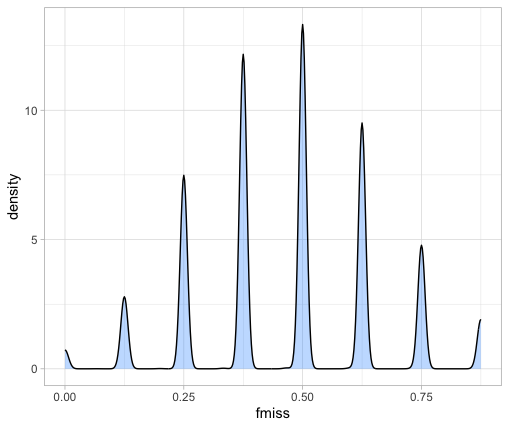

```bash
a <- ggplot(var_miss, aes(fmiss)) + geom_density(fill = "dodgerblue1", colour = "black", alpha = 0.3)
a + theme_light()
```

Our milkfish target capture data has a mix missingness profile - clearly most individuals have a missing call at 50% of the sites. Indeed if we look at the summary of the data we can see this even more clearly.

```bash
summary(var_miss$fmiss)
```

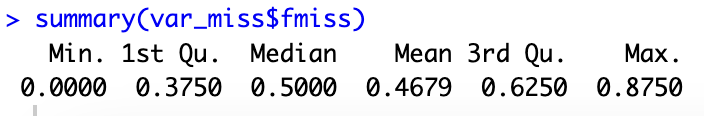

Fig 5. Summary missingness).

##### 2.4. Minor allele frequency

Last of all for our per variant analyses, we will take a look at the distribution of allele frequencies. This will help inform our minor-allele frequency (MAF) thresholds. As previously, we read in the data:

```bash
var_freq <- read_delim(""./milkfish_filtered.frq, delim = "\t",
                       col_names = c("chr", "pos", "nalleles", "nchr", "a1", "a2"), skip = 1)
```

However, this is simply the allele frequencies. To find the minor allele frequency at each site, we need to use a bit of dplyr based code.

```bash
# find minor allele frequency
var_freq$maf <- var_freq %>% select(a1, a2) %>% apply(1, function(z) min(z))
```

Here we used `apply` on our allele frequencies to return the lowest allele frequency at each variant. We then added these to our dataframe as the variable `maf`. Next we will plot the distribution:

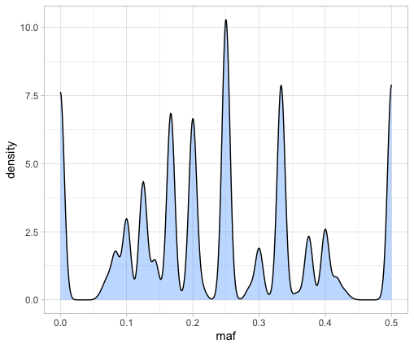

Fig 6. Minor allel frequency (MAF)).

```bash
a <- ggplot(var_freq, aes(maf)) + geom_density(fill = "dodgerblue1", colour = "black", alpha = 0.3)
a + theme_light()
```

The distribution might look a little odd - this is partly because of the low number of individuals we have in the dataset (8), meaning there are only certain frequencies possible. Nonetheless, it is clear that a large number of variants have low frequency alleles. We can also look at the distribution in more detail:

```bash
summary(var_freq$maf)
```

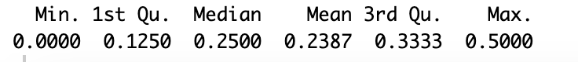

Fig 7. MAF summary).

The upper bound of the distribution is 0.5, which makes sense because if MAF was more than this, it wouldn’t be the MAF! How do we interpret MAF? It is an important measure because low MAF alleles may only occur in one or two individuals. It is possible that some of these low frequency alleles are in fact unreliable base calls - i.e. a source of error.

With 8 individuals, there are 16 alleles for a given site. Therefore MAF = 0.04 is equivalent to a variant occurring as one allele in a single individual (i.e. 16 * 0.04 = 0.64). Alternatively, an MAF of 0.1 would mean that any allele would need to occur at least twice (i.e. 16 * 0.1 = 1.6).

Setting MAF cutoffs is actually not that easy or straightforward. Hard MAF filtering (i.e. setting a high threshold) can severely bias estimation of the site frequency spectrum `SFS` and cause problems with demographic analyses. Similarly, an excesss of low frequency, ‘singleton’ SNPs (i.e. only occurring in one individual) can mean you keep many uniformative loci in your dataset that make it hard to model things like population structure.

Usually then, it is best practice to produce one dataset with a good MAF threshold and keep another without any MAF filtering at all. For now however, we will set our MAF to 0.1

### 3. Individual based statistics

As well as a our per variant statistics we generated earlier, we also calculated some individual metrics too. We can look at the distribution of these to get an idea whether some of our individuals have not sequenced or mapped as well as others. This is good practice to do with a new dataset. A lot of these statistics can be compared to other measures generated from the data (i.e. principal components as a measure of population structure) to see if they drive any apparent patterns in the data.

##### 3.1. Mean depth per individual

First we will look at the distribution of mean depth among individuals. We read the data in with `read_delim`:

```bash
ind_depth <- read_delim("milkfish_filtered.idepth", delim = "\t",
                        col_names = c("ind", "nsites", "depth"), skip = 1)
```

Then we plot the distribution as a histogram using `ggplot` and `geom_hist`.

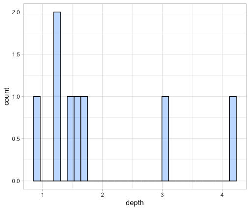

Fig 8. Mean depth per individual).

```bash
a <- ggplot(ind_depth, aes(depth)) + geom_histogram(fill = "dodgerblue1", colour = "black", alpha = 0.3)
a + theme_light()
```

Because we are only plotting data for 8 individuals, the plot looks a little disjointed. While there is some evidence that some individuals were sequenced to a higher depth than others, there are no extreme outliers. So this doesn’t suggest any issue with individual sequencing depth.

##### 3.2. Proportions of missing data per individual

Next we will look at the proportion of missing data per individual. We read in the data below:

```bash
ind_miss  <- read_delim("milkfish_filtered.imiss", delim = "\t",
                        col_names = c("ind", "ndata", "nfiltered", "nmiss", "fmiss"), skip = 1)
```

This is very similar to the `missing data per site`. Here we will focus on the `fmiss` column - i.e. the proportion of missing data.

```bash
a <- ggplot(ind_miss, aes(fmiss)) + geom_histogram(fill = "dodgerblue1", colour = "black", alpha = 0.3)
a + theme_light()
```

This analysis confirms that the proportion of missing data per individual is quite substantial, ranging from 0.1 to 0.68. Given this high variability, we cannot confidently say that all individuals were sequenced well.

The good news is that we have a large number of reads available, so the situation may improve as we incorporate more individuals into the analysis.

To address this issue, we have two options:

First, filter out individuals with more than 50% missing data to ensure higher-quality samples.

Second, reduce the number of SNP sites, keeping only those where the majority of individuals have available data, thereby retaining more individuals in the dataset.

The choice between these approaches will depend on the balance between sample representation and dataset completeness.

[figure not shown]

Fig 9. Proportion of missing data per individual).

##### 3.3. Heterozygosity and inbreeding coefficient per individual

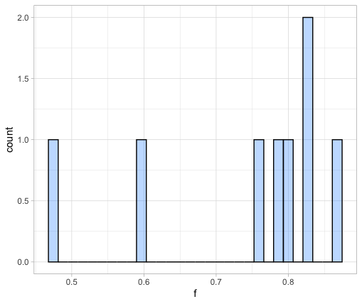

Fig 10. Heterozygosity and inbreeding coefficient per individual).

```bash
ind_het <- read_delim("milkfish_filtered.het", delim = "\t",
                      col_names = c("ind","ho", "he", "nsites", "f"), skip = 1)


#Plot

a <- ggplot(ind_het, aes(f)) + geom_histogram(fill = "dodgerblue1", colour = "black", alpha = 0.3)
a + theme_light()
```

Since we are analyzing a single species, the observed inbreeding may be due to non-random mating, population structuring, or a historical bottleneck rather than the Wahlund effect.

### 4. Applying filters to the VCF

Now we have an idea of how to set out thresholds, we will do just that. First of all, we will set some simple variables in order to make our filtering command more straightforward.

I want you to create a bash script inputting all the values we wanted to put as cut-off values based on our pre-data analyses:

```bash
#!/bin/bash

##Applying filters to the VCF

VCF_IN=/home/apl/NAS_apl/milkfish/milkfish_snps_filtered.vcf.gz
VCF_OUT=/home/apl/NAS_apl/milkfish/full_filter_nomaf_milkfish_snps_filtered.vcf.gz

# set filters
#MAF=0.1 # we will not set MAF on this one
MISS=0.8
QUAL=25
MIN_DEPTH=0.5
MAX_DEPTH=4

vcftools --gzvcf $VCF_IN \
--remove-indels --max-missing $MISS --minQ $QUAL \
--min-meanDP $MIN_DEPTH --max-meanDP $MAX_DEPTH \
--minDP $MIN_DEPTH --maxDP $MAX_DEPTH --recode --stdout | gzip -c > \
$VCF_OUT
```

Try running this command with your `milkfish_snps_filtered.vcf.gz` dataset saved on `dataset` directory.

### Can you count the number of SNPs left on your filtered vcf file?

```bash
bcftools view -H full_filter_nomaf_milkfish_snps_filtered.vcf.gz | wc -l
```

### How many SNPs were removed? How many are left?

### Answer: 134,078 SNPs left

Lets dissect what we have done here.

What have we done here?

–gvcf - input path – denotes a gzipped vcf file

–remove-indels - remove all indels (SNPs only)

–maf - set minor allele frequency - 0.1 here ## not applied

–max-missing - set minimum non-missing data. A little counterintuitive - 0 is totally missing, 1 is none missing. Here 0.8 means we will tolerate 20% missing data.

–minQ - this is just the minimum quality score required for a site to pass our filtering threshold. Here we set it to 25.

–min-meanDP - the minimum mean depth for a site.

–max-meanDP - the maximum mean depth for a site.

–minDP - the minimum depth allowed for a genotype - any individual failing this threshold is marked as having a missing genotype.

–maxDP - the maximum depth allowed for a genotype - any individual failing this threshold is marked as having a missing genotype.

–recode - recode the output - necessary to output a vcf

–stdout - pipe the vcf out to the stdout (easier for file handling)

### Note: You can adjust this value based on your sequencing dataset. If you have a large number of SNPs, a strict (hard) filtering approach may be appropriate. Conversely, if you have fewer SNPs, a more relaxed (soft) filtering might be preferable.

### The key takeaway is that you must understand and justify your chosen threshold. Reviewers often request explanations for filtering decisions, so it’s essential to provide a clear rationale for why a specific cutoff was selected.

## Congratulations! You can now see that we have substantially filtered our dataset